# Spam Detection: Naive Bayes vs SVM

**Student Name:** Thomas Jones **Date:** 2/18/2026

In this project, you'll:

1. Load a spam email dataset
2. Train a Naive Bayes classifier
3. Train an SVM classifier
4. Compare the results

*Note*: This project was created with the assistance of AI

## Step 1: Import Libraries and Load Data

```python
# Import libraries
import numpy as np
import pandas as pd

# Set random seed for reproducibility
np.random.seed(42)
```

```python
# Load the dataset
df = pd.read_csv('../data/spam_data.csv')

# Display first few rows
df.head()
```

|  | word_free | word_money | word_winner | word_click | word_urgent | num_exclamation | num_dollar | num_capitals | email_length | has_link | is_spam |
| --- | --- | --- | --- | --- | --- | --- | --- | --- | --- | --- | --- |
| 0 | 0.116603 | 0.081405 | 0.248621 | 0.107026 | 0.084280 | 0.162809 | 0.042277 | 0.240659 | 101.836546 | 0.296066 | 0 |
| 1 | 0.150017 | 0.202468 | 0.071720 | 0.227412 | 0.228002 | 0.093779 | 0.123205 | 0.062907 | 90.571442 | 0.193681 | 0 |
| 2 | 0.009429 | 0.190923 | 0.094307 | 0.152571 | 0.272270 | 0.074788 | 0.123115 | 0.226665 | 130.369345 | 0.023094 | 0 |
| 3 | 0.085727 | 0.129830 | 0.205633 | 0.099737 | 0.016976 | 0.112176 | 0.283335 | 0.192520 | 98.526674 | 0.189685 | 0 |
| 4 | 0.050113 | 0.050286 | 0.011001 | 0.220921 | 0.199141 | 0.142389 | 0.253251 | 0.241701 | 96.637459 | 0.260481 | 0 |

## Step 2: Preprocessing the Data

- Clean the data
- Split the data into training and test sets.
- Feature Scaling

```python
# Clean the data
print("Null counts:")
print(df.isna().sum())

print("\nSpam/Not Spam distribution:")
print(df['is_spam'].value_counts())

print("\nMax values for each column:")
print(df.max())

print("\nMin values for each column:")
print(df.min())

from sklearn.preprocessing import MinMaxScaler
scaler = MinMaxScaler()

# Scale specific columns
columns_to_scale = ['word_money', 'word_winner', 'word_urgent', 'num_exclamation', 'num_dollar', 'email_length']
df[columns_to_scale] = scaler.fit_transform(df[columns_to_scale])

print("\nMax values for each column after scaling:")
print(df.max())

print("\nMin values for each column after scaling:")
print(df.min())
```

```
Null counts:
word_free          0
word_money         0
word_winner        0
word_click         0
word_urgent        0
num_exclamation    0
num_dollar         0
num_capitals       0
email_length       0
has_link           0
is_spam            0
dtype: int64

Spam/Not Spam distribution:
is_spam
0    600
1    400
Name: count, dtype: int64

Max values for each column:
word_free            0.997347
word_money           1.498341
word_winner          1.491796
word_click           0.998332
word_urgent          1.497016
num_exclamation      1.998248
num_dollar           1.990861
num_capitals         0.999604
email_length       149.946068
has_link             0.995018
is_spam              1.000000
dtype: float64

Min values for each column:
word_free           0.001814
word_money          0.000009
word_winner         0.000003
word_click          0.001728
word_urgent         0.000040
```

[output cut: 20 more lines]

```
dtype: float64

Min values for each column after scaling:
word_free          0.001814
word_money         0.000000
word_winner        0.000000
word_click         0.001728
word_urgent        0.000000
num_exclamation    0.000000
num_dollar         0.000000
num_capitals       0.000470
email_length       0.000000
has_link           0.000334
is_spam            0.000000
dtype: float64
```

```python
from sklearn.model_selection import train_test_split

# Split the data using a random state of 42 for reproducibility
X = df.drop('is_spam', axis=1)
y = df['is_spam']
X_train, X_test, y_train, y_test = train_test_split(X, y, test_size=0.20, random_state=42)
```

## Step 3: Train Naive Bayes Classifier

```python
from sklearn.naive_bayes import GaussianNB
model = GaussianNB()
model.fit(X_train, y_train)
```

```
GaussianNB()
```

```python
from sklearn.metrics import confusion_matrix, classification_report
y_pred_naive_bayes = model.predict(X_test)
```

Display your confusion matrix and your classification report.

```python
print(f"Confusion Matrix:\n{confusion_matrix(y_test, y_pred_naive_bayes)}")
print(f"\nClassification Report:\n{classification_report(y_test, y_pred_naive_bayes)}")
```

```
Confusion Matrix:
[[113   0]
 [  0  87]]

Classification Report:
              precision    recall  f1-score   support

           0       1.00      1.00      1.00       113
           1       1.00      1.00      1.00        87

    accuracy                           1.00       200
   macro avg       1.00      1.00      1.00       200
weighted avg       1.00      1.00      1.00       200
```

## Step 4: Train k-Nearest Neighbors Classifier

```python
from sklearn.neighbors import KNeighborsClassifier

knc = KNeighborsClassifier(n_neighbors=31, metric='euclidean')
knc.fit(X_train, y_train)
```

```
KNeighborsClassifier(metric='euclidean', n_neighbors=31)
```

```python
y_pred_k_nearest = knc.predict(X_test)
```

Display your confusion matrix and classification report.

```python
print(f"Confusion Matrix:\n{confusion_matrix(y_test, y_pred_k_nearest)}")
print(f"\nClassification Report:\n{classification_report(y_test, y_pred_k_nearest)}")
```

```
Confusion Matrix:
[[113   0]
 [  0  87]]

Classification Report:
              precision    recall  f1-score   support

           0       1.00      1.00      1.00       113
           1       1.00      1.00      1.00        87

    accuracy                           1.00       200
   macro avg       1.00      1.00      1.00       200
weighted avg       1.00      1.00      1.00       200
```

## Step 5: Train SVM Classifier

```python
from sklearn.svm import SVC
from sklearn.pipeline import Pipeline
from sklearn.preprocessing import StandardScaler

polykernel_svm_clf = Pipeline([
    ("scaler", StandardScaler()),
    ("svm_clf", SVC(kernel="poly", degree=1, coef0=1, C=5))
])

polykernel_svm_clf.fit(X_train, y_train)
```

```
Pipeline(steps=[('scaler', StandardScaler()),
                ('svm_clf', SVC(C=5, coef0=1, degree=1, kernel='poly'))])
```

```python
y_pred_svm = polykernel_svm_clf.predict(X_test)
```

Display your confusion matrix and your classification report.

```python
print(f"Confusion Matrix:\n{confusion_matrix(y_test, y_pred_svm)}")
print(f"\nClassification Report:\n{classification_report(y_test, y_pred_svm)}")
```

```
Confusion Matrix:
[[113   0]
 [  0  87]]

Classification Report:
              precision    recall  f1-score   support

           0       1.00      1.00      1.00       113
           1       1.00      1.00      1.00        87

    accuracy                           1.00       200
   macro avg       1.00      1.00      1.00       200
weighted avg       1.00      1.00      1.00       200
```

## Step 6: Compare the Models

- Create graphs that compare model results
- Make calculations to compare model results

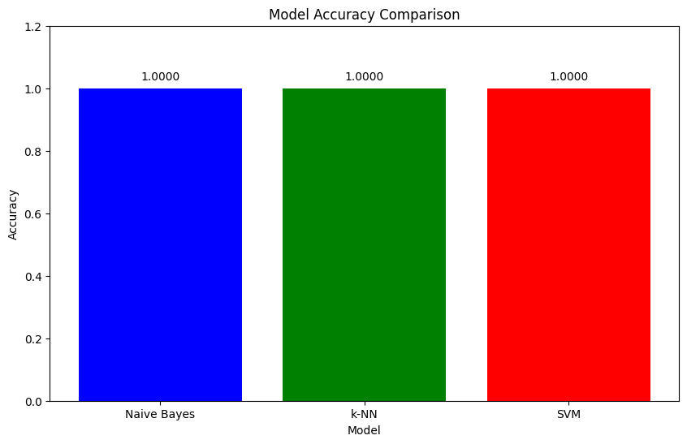

```
Naive Bayes Accuracy: 1.0000
k-NN Accuracy: 1.0000
SVM Accuracy: 1.0000
```

```python
import matplotlib.pyplot as plt
from sklearn.metrics import accuracy_score

# Calculate accuracy for each model
nb_accuracy = float(accuracy_score(y_test, y_pred_naive_bayes))
knn_accuracy = float(accuracy_score(y_test, y_pred_k_nearest))
svm_accuracy = float(accuracy_score(y_test, y_pred_svm))

# Create bar graph
models = ['Naive Bayes', 'k-NN', 'SVM']
accuracies = [nb_accuracy, knn_accuracy, svm_accuracy]

plt.figure(figsize=(10, 6))
plt.bar(models, accuracies, color=['blue', 'green', 'red'])
plt.xlabel('Model')
plt.ylabel('Accuracy')
plt.title('Model Accuracy Comparison')
plt.ylim([0, 1.2])
for i, acc in enumerate(accuracies):
    plt.text(i, acc + 0.02, f'{acc:.4f}', ha='center', va='bottom')
plt.show()

print(f"Naive Bayes Accuracy: {nb_accuracy:.4f}")
print(f"k-NN Accuracy: {knn_accuracy:.4f}")
print(f"SVM Accuracy: {svm_accuracy:.4f}")
```

Discuss the results of your comparison.

## Step 7: Answer Discussion Questions

Based on your results, answer the following questions:

### Question 1: Which model performed better overall? Why do you think so?

**Your Answer:**

All of the models performed at 100% accuracy. There was not a single model that performed lower.

### Question 2: What is the difference between accuracy and precision? Which is more important for spam detection?

**Your Answer:**

Accuracy is the proportion of predictions that were correct (positive and negative), while precision is the ratio of true positives to predicted positives (true and false).

### Question 3: When would you choose Naive Bayes over kNN or SVM in a real-world application?

**Your Answer:**

You would choose Naive Bayes over KNN and SVM when you are certain that the variables in the model are independent. Naive Bayes also works best if the data is distributed normally.

### Question 4: What are the key assumptions of Naive Bayes? Do you think they hold true for this spam detection problem?

**Your Answer:**

Naive Bayes assumes that the features are independent. In this dataset, the independence assumption does not hold. If one of the word features is present in an email, it can be more likely for other word features to appear.

### Question 5: How did you determine your value for $k$ in the kNN model?

**Your Answer:**

We chose the value of k by taking the square root of the total number of data points, and then finding the prime number closest to that value. The square root of 1000 is ~31.62, so the closest prime number was 31.

## Summary

**Key Takeaways:**

1. Different algorithms can produce different results on the same data
2. Multiple metrics (accuracy, precision, recall) give a complete picture
3. Both Naive Bayes and SVM are effective for classification tasks
4. The choice of algorithm depends on the specific requirements of your problem